# Data exploration - Stratified random surveys (StRS) of reef fish in the U.S. Pacific Islands

In this notebook we explore the [NOAA Pacific Islands Fisheries Science Center, Ecosystem Sciences Division, National Coral Reef Monitoring Program: Stratified random surveys (StRS) of reef fish in the U.S. Pacific Islands](https://obis.org/dataset/2ae2a2bd-8412-405b-8a9f-b71adc41d4c5) dataset.

# Data preparation

First load some packages, get the world polygons for creating maps, and initialize a cache.

```r
library(robis)
library(dplyr)
library(ggplot2)
library(sf)
library(rnaturalearth)
library(memoise)
library(cachem)

world <- ne_countries(scale = "medium", returnclass = "sf")
cache <- cachem::cache_disk(dir = "cache", max_size = Inf)
```

## Fetching data from the OBIS API

Fetch occurrence data from OBIS and make sure to include the MeasurementOrFact records. This step can take a while, so I’m using a local cache to speed up subsequent runs.

```r
occ <- memoise(occurrence, cache = cache)(datasetid = "2ae2a2bd-8412-405b-8a9f-b71adc41d4c5", mof = TRUE)
```

## Cleanup occurrence

`individualCount`s are provided as character, so first convert to numeric:

```r
occ <- occ %>%
  mutate(individualCount = as.numeric(individualCount))
```

## Extract measurements

The MeasurementOrFact records are nested inside the `mof` column, use `unnest_extension()` to extract them to a dedicated data frame.

```r
mof <- unnest_extension(occ, "MeasurementOrFact", fields = c("eventID", "scientificName", "year", "individualCount", "decimalLongitude", "decimalLatitude", "island", "islandGroup", "stateProvince"))
```

## Cleanup measurements

The consumer types are a bit cryptic, so let’s translate them to something human readable:

```r
mof <- mof %>%
  mutate(measurementValue = recode(measurementValue,
    APEX = "apex predator",
    Cor = "corallivore",
    H = "herbivore",
    MI = "mobile invertivore",
    Om = "omnivore",
    Par = "parrotfish",
    Pisc = "piscivore",
    Pk = "planktivore",
    SI = "sessile invertivore",
    X = "unidentified fish",
    Z = "zooplantivore"
  ))
```

# Data exploration

## Time

Let’s take a look at the time distribution of our dataset:

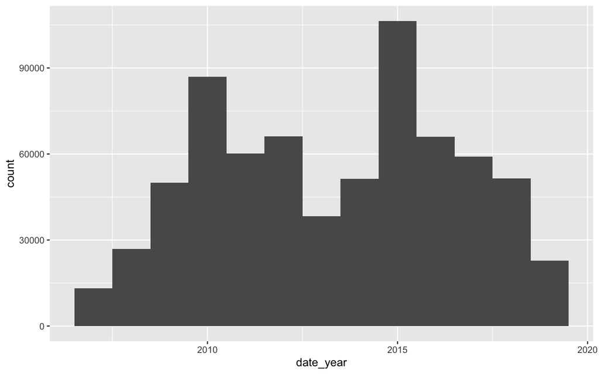

```r
ggplot(data = occ) +
  geom_bar(aes(date_year), width = 1)
```

## Locations

Check how many locations we have at different levels (station, island, island group):

```r
occ %>%
  group_by(decimalLongitude, decimalLatitude) %>%
  summarize(records = n()) %>%
  arrange(desc(records))
```

```
## # A tibble: 6,632 × 3
## # Groups:   decimalLongitude [6,619]
##    decimalLongitude decimalLatitude records
##               <dbl>           <dbl>   <int>
##  1            -178.          28.4       368
##  2            -176.           0.198     338
##  3             146.          17.3       286
##  4             145.          20.0       277
##  5            -162.           5.87      276
##  6             146.          17.6       271
##  7             146.          17.3       268
##  8            -162.           6.39      266
##  9             145.          20.0       266
## 10             145.          20.0       264
## # … with 6,622 more rows
```

```r
occ %>%
  group_by(island) %>%
  summarize(records = n()) %>%
  arrange(desc(records))
```

```
## # A tibble: 45 × 2
##    island         records
##    <chr>            <int>
##  1 Tutuila          75141
##  2 Guam             40308
##  3 Jarvis           33195
##  4 Hawaii           31437
##  5 Palmyra          30140
##  6 Rose             25805
##  7 Pearl & Hermes   24544
##  8 Kingman          23721
##  9 Tau              23437
## 10 French Frigate   21087
## # … with 35 more rows
```

```r
occ %>%
  group_by(islandGroup) %>%
  summarize(records = n()) %>%
  arrange(desc(records))
```

```
## # A tibble: 6 × 2
##   islandGroup                   records
##   <chr>                           <int>
## 1 American Samoa                 160912
## 2 Mariana Archipelago            145489
## 3 Pacific Remote Island Areas    145140
## 4 Main Hawaiian Islands          115367
## 5 Northwestern Hawaiian Islands  113250
## 6 Coral Triangle                  18742
```

## Count data in individualCount

Let’s take a look at the counts for a single species and a single island.

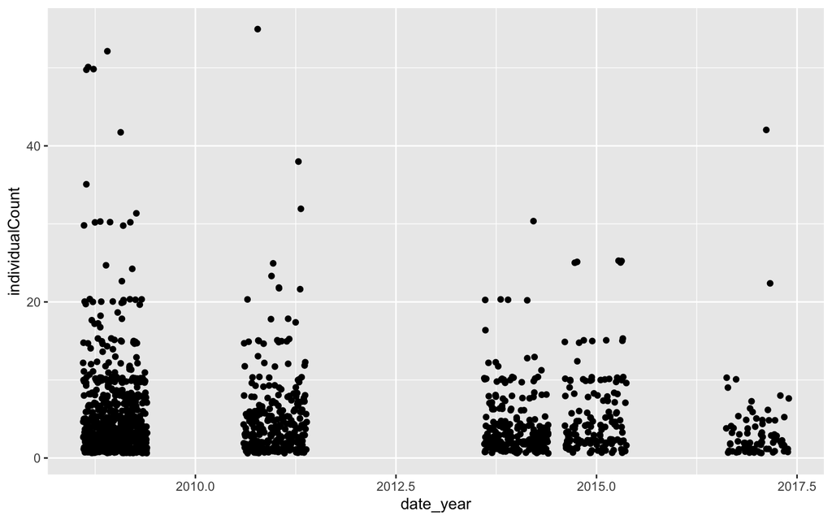

```r
thadup <- occ %>%
  filter(scientificName =="Thalassoma duperrey" & island == "Midway")

ggplot(thadup) +
  geom_jitter(aes(date_year, individualCount))
```

## Measurement types

Let’s first take a look at all `measurementType`s and `measurementTypeID`s (if any):

```r
library(knitr)

mt <- mof %>%
  group_by(measurementType, measurementTypeID) %>%
  summarize(records = n()) %>%
  arrange(desc(records))

mt %>%
  kable()
```

| measurementType | measurementTypeID | records |
| --- | --- | --- |
| “LW_A” Fish Species Parameter used in length-weight calculations | NA | 698900 |
| “LW_B” Fish Species Parameter used in length-weight calculations | NA | 698900 |
| Consumer type: APEX (apex predator), Cor (corallivore), H (herbivore), MI (mobile invertivore), Om (Omnivore), Par (parrotfish), Pisc (piscivore), Pk (planktivore), SI (sessile invertivore), X (if uni… | NA | 698900 |
| Theoretical maximum length for fish species | NA | 698900 |
| Length conversion factor used to determine fish max length | NA | 698899 |
| Trophic level (Primary Consumer, Secondary Consumer, Planktivore, Piscivore) | NA | 698874 |
| Number of individuals of a species of the same length observed within a given time | NA | 698863 |
| Fish Total Length, TL | NA | 698630 |
| Crustose Coralline Algae Substrate Cover | NA | 604946 |
| Hard Coral Substrate Cover | NA | 604946 |
| Macroalgae Substrate Cover | NA | 604946 |
| Sand Substrate Cover | NA | 604916 |
| Underwater Visibility | NA | 544205 |
| Current Strength (None, Slight, Moderate, High) | NA | 543349 |
| Proportion of survey area between 0 cm and 20 cm elevation above seafloor depth | NA | 461677 |
| Proportion of survey area between 100 cm and 150 cm elevation above seafloor depth | NA | 461677 |
| Proportion of survey area between 20 cm and 50 cm elevation above seafloor depth | NA | 461677 |
| Proportion of survey area between 50 cm and 100 cm elevation above seafloor depth | NA | 461677 |
| Proportion of survey area over 150 cm elevation above seafloor depth | NA | 461677 |
| Highest elevation point of substrate above seafloor depth in SPC cylinder | NA | 461665 |
| Boring urchin abundance, estimated by DACOR, an abundance code based on visual estimation (Dominant, Abundant, Common, Occasional, and Rare) | NA | 461627 |
| Free urchin abundance, estimated by DACOR, an abundance code based on visual estimation (Dominant, Abundant, Common, Occasional, and Rare) | NA | 461627 |
| Turf Algae Substrate Cover | NA | 405523 |
| Soft Coral Substrate Cover | NA | 399476 |
| Bivalve Substrate Cover | NA | 340936 |
| Corallimorpharian Substrate Cover | NA | 340936 |
| Tunicate Substrate Cover | NA | 340936 |
| Zoantharian Substrate Cover | NA | 340936 |
| Cyanobacteria Substrate Cover | NA | 318563 |
| Sponge Substrate Cover | NA | 162617 |

### Trophic level

Aggregate the count data by island and trophic level (Primary Consumer, Secondary Consumer, Planktivore, Piscivore):

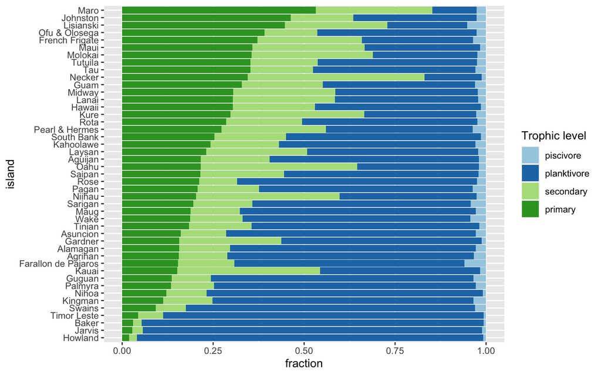

```r
mof_trophic <- mof %>%
  filter(measurementType == "Trophic level (Primary Consumer, Secondary Consumer, Planktivore, Piscivore)" & !is.na(individualCount)) %>%
  mutate(measurementValue = factor(tolower(measurementValue), levels = c("piscivore", "planktivore", "secondary", "primary")))

trophic_stats <- mof_trophic %>%
  group_by(island) %>%
  mutate(individuals = sum(individualCount)) %>%
  group_by(island, measurementValue) %>%
  summarize(fraction = sum(individualCount / individuals))

island_order <- trophic_stats %>% filter(measurementValue == "primary") %>% arrange(fraction) %>% pull(island)

trophic_stats$island <- factor(trophic_stats$island, levels = island_order)

ggplot(trophic_stats) +
  geom_bar(aes(island, fraction, fill = measurementValue), position = "stack", stat = "identity") +
  coord_flip() +
  labs(fill = "Trophic level") +
  scale_fill_brewer(palette = "Paired")
```

### Consumer types

Aggregate the count data by island and consumer type:

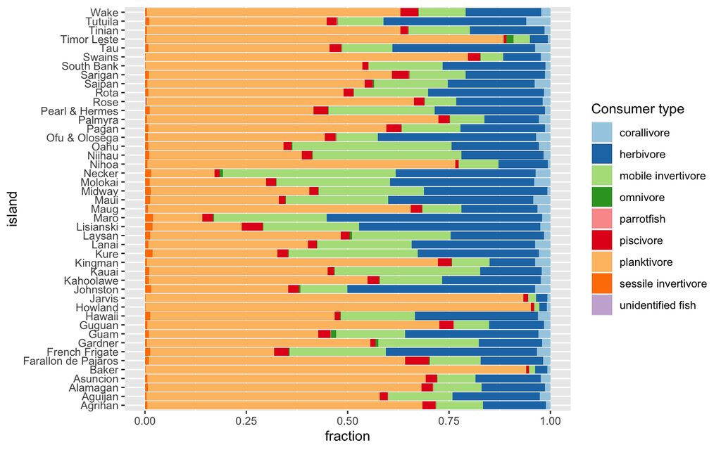

```r
mof_consumer <- mof %>%
  filter(measurementType == "Consumer type: APEX (apex predator), Cor (corallivore), H (herbivore), MI (mobile invertivore), Om (Omnivore), Par (parrotfish), Pisc (piscivore), Pk (planktivore), SI (sessile invertivore), X (if unidentified fish), Z (zooplantivore)" & !is.na(individualCount))

consumer_stats <- mof_consumer %>%
  group_by(island) %>%
  mutate(individuals = sum(individualCount)) %>%
  group_by(island, measurementValue) %>%
  summarize(fraction = sum(individualCount / individuals))

ggplot(consumer_stats) +
  geom_bar(aes(island, fraction, fill = measurementValue), position = "stack", stat = "identity") +
  coord_flip() +
  labs(fill = "Consumer type") +
  scale_fill_brewer(palette = "Paired")
```

### Length

Calculate mean fish length by island:

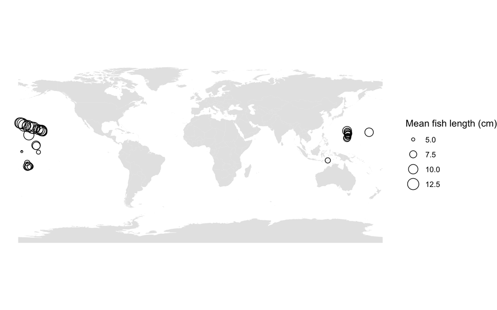

```r
mof_length <- mof %>%
  filter(measurementType == "Fish Total Length, TL") %>%
  mutate(measurementValue = as.numeric(measurementValue))

length_stats <- mof_length %>%
  group_by(island) %>%
  summarize(
    decimalLongitude = mean(decimalLongitude),
    decimalLatitude = mean(decimalLatitude),
    mean_length = sum(measurementValue * individualCount) / sum(individualCount),
    median_length = median(rep(measurementValue, individualCount)),
    q1_length = quantile(rep(measurementValue, individualCount))[2],
    q3_length = quantile(rep(measurementValue, individualCount))[4],
    sd_length = sd(rep(measurementValue, individualCount))
  ) %>%
  st_as_sf(coords = c("decimalLongitude", "decimalLatitude"), crs = 4326)

length_stats$island <- reorder(length_stats$island, length_stats$mean_length)

ggplot() +
  geom_sf(data = world, color = NA) +
  geom_sf(data = length_stats, aes(size = mean_length), fill = NA, shape = 21) +
  scale_size(range = c(0, 6), name = "Mean fish length (cm)") +
  theme_void()
```

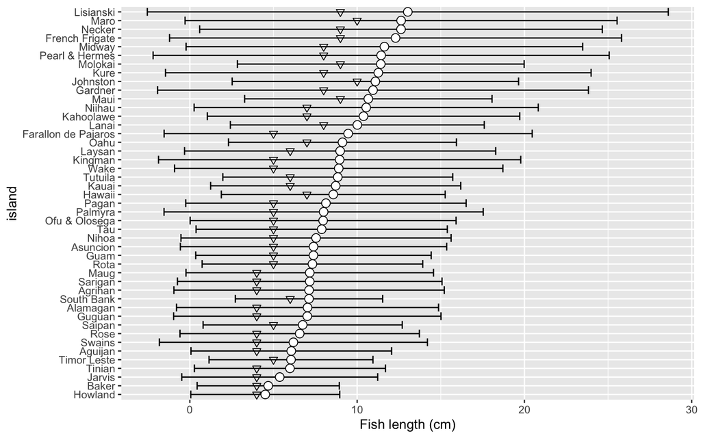

```r
ggplot(length_stats) +
  geom_errorbarh(aes(y = island, xmin = mean_length - sd_length, xmax = mean_length + sd_length)) +
  geom_point(aes(y = island, x = mean_length), shape = 21, fill = "white", size = 3) +
  geom_point(aes(y = island, x = median_length), shape = 6, fill = "white", size = 2) +
  xlab("Fish length (cm)")
```